# simpok_game

### Proof of optimal strategy

In a symmetric game, an optimal strategy must be an optimal response to itself. We can hope to find an optimal strategy such that the bet is a nondecreasing function of the hand. Let's assume $g_2$ is using the optimal strategy shown above. We show if $x_1<(1-\sqrt{a})$ then $u_1=-a$ regardless of $b_1$.

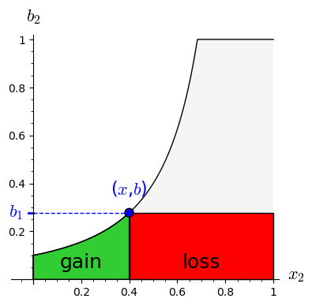

```python
var("a x b")
b(a,x) = min_symbolic(a/(1-x)^2,1)
a0 = 0.1
b1 = a0/(1-0.4)^2
p = plot(b(a0,x),(0,1),ymin=0,ymax=1,xmin=0,xmax=1,aspect_ratio=1,axes_labels=['$x_2$','$b_2$'],color="black")
L = [[0,0]]+[[i/200,min_symbolic(1,a0/(1-i/200)^2)] for i in range(200+1)]+[[1,0]]
p += polygon(L, edgecolor="white", color=Color(0.96,0.96,0.96))
L = [[0,0]]+[[i/100,a0/(1-i/100)^2] for i in range(40+1)]+[[0.4,0]]
p += polygon(L,color="limegreen", edgecolor="black")
p += polygon([[0.4,b1],[1,b1],[1,0],[0.4,0]],color="red", edgecolor="black")
p += text("gain",(0.2,0.07),fontsize=18,color="black")
p += text("loss",(0.7,0.07),fontsize=18,color="black")
p += text("$b_1$",(-0.07,b1),fontsize=16,vertical_alignment="center")
p += line([(-0.02,b1),(0,b1)],thickness=2)
p += line([(0,b1),(0.4,b1)],linestyle="--")
p += circle((0.4,b1),0.018,fill=True,edgecolor="black")
p += text("($x$,$b$)",(0.4,b1+0.1),fontsize=16)
show(p)
```

```python
a = var("a")
x = var("x")
b = a/(1-x)^2
u1 = function("u1")(x)
assume(x>0)
assume(x<1)
eq = (u1(x) == integrate(b,x,0,x)-(1-x)*b)
show(eq.simplify_full())
```

$$\newcommand{\Bold}[1]{\mathbf{#1}}u_{1}\left(x\right) = -a$$

If $x_1\ge(1-\sqrt{a})$ then $g_1$ optimizes with $b_1=1$. If $b_1<1$ then $u_1=-a$. Only by going all-in can $g_1$ take advantage of high hands.

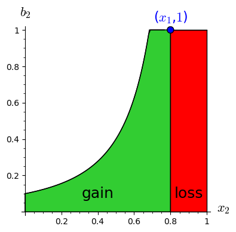

```python
var("a x b")
b(a,x) = min_symbolic(a/(1-x)^2,1)
a0 = 0.1
xx = 0.8
b1 = 1 #a0/(1-0.4)^2
p = plot(b(a0,x),(0,1),ymin=0,ymax=1,xmin=0,xmax=1,aspect_ratio=1,axes_labels=['$x_2$','$b_2$'],color="black")
L = [[0,0]]+[[i/200,min_symbolic(1,a0/(1-i/200)^2)] for i in range(200+1)]+[[1,0]]
p += polygon(L, edgecolor="white", color=Color(0.96,0.96,0.96))
L = [[0,0]]+[[i/100,b(a0,i/100)] for i in range(int(xx*100)+1)]+[[xx,0]]
p += polygon(L,color="limegreen", edgecolor="black")
p += polygon([[xx,b1],[1,b1],[1,0],[xx,0]],color="red", edgecolor="black")
p += text("gain",(0.4,0.1),fontsize=18,color="black")
p += text("loss",(0.9,0.1),fontsize=18,color="black")
p += circle((xx,b1),0.018,fill=True,edgecolor="black")
p += text("($x_1$,$1$)",(xx,b1+0.07),fontsize=16)
show(p)
```

Thus, there is no benefit for $g_1$ to not using a symmetric strategy, proving the Nash equilibrium.

However, it is also clear that $g_1$ can use any strategy (as long as she goes all-in on good hands) and still have a 0 expected profit. Thus this is a weak Nash equilibrium. Also, if $g_1$ were to change her strategy (while maintaining 0 net profit), then $g_2$ could respond to net a higher profit; thus this is an unstable equilibrium.

### Derivation of optimal solution

Assume $b_2(x_2)$ is a continuous increasing function up to the ceiling (at a critical hand) and all-in for hands above critical. If $g_1$ bets below 1, the expected profit can depend on $b_1$, and the corresponding hand that would cause $g_2$ to bet $b_1$. That value will be called $x$. Also, because $b_1=b_2(x)$, we can just use $b$. $$$$ $$\begin{align}\text{if }b_1<1:&\\x &= b_2^{-1}(b_1) \\\\ u_1 &= \int_0^xb_2(x_2) dx_2 - (1-x)b\end{align}$$

The trick is to enforce no profit difference to $g_1$ when changing the bet.

```python
a = var("a")
x = var("x")
c = var("c")
u1 = function("u1")(x)
b = function('b')(x)
eq = (u1(x) == b.integral(x)-(1-x)*b)
eq2 = (0 == diff(eq).rhs())
eq3 = (b == desolve(eq2,b,[0,a]).factor())
show(eq3)
assume(x<1)
show(solve(eq3.rhs()==1,x)[0].substitute(x=c))
```

$$\newcommand{\Bold}[1]{\mathbf{#1}}b\left(x\right) = \frac{a}{{\left(x - 1\right)}^{2}}$$

$$\newcommand{\Bold}[1]{\mathbf{#1}}c = -\sqrt{a} + 1$$

## Simultaneous, continuous, $n$-gambler poker

A similar logic can find a Nash equilibrium in an $n$-gambler version. We assume all gamblers are using the same strategy, and ask whether $g_1$ can improve by changing strategy.

First, if $x_1<c$, then $g_1$ will pick a bet $b_1$. We will find the $x$ that corresponds to this bet, and call that bet $b$ for simplicity.

$$\text{if }x_1<c: $$$$u_1 = x^{n-1}(n-1)\frac{1}{x}\int_0^x b(x) dx - (1-x^{n-1})b $$

```python
var("a x")
b=function("b")(x)
u1=function("u1")(x)
eq1 = (u1(x)==x^6*6/x*b.integral(x)-(1-x^6)*b)
show(eq1)
show(diff(eq1,x))
bsol = desolve(diff(eq1,x).rhs(),b,ivar=x).log_simplify().simplify_full()
show(bsol.log_simplify().factor())
latex(bsol)
```

$$\newcommand{\Bold}[1]{\mathbf{#1}}u_{1}\left(x\right) = 6 \, x^{5} \int b\left(x\right)\,{d x} + {\left(x^{6} - 1\right)} b\left(x\right)$$

$$\newcommand{\Bold}[1]{\mathbf{#1}}\frac{\partial}{\partial x}u_{1}\left(x\right) = 12 \, x^{5} b\left(x\right) + 30 \, x^{4} \int b\left(x\right)\,{d x} + {\left(x^{6} - 1\right)} \frac{\partial}{\partial x}b\left(x\right)$$

$$\newcommand{\Bold}[1]{\mathbf{#1}}\frac{C}{{\left(x^{2} + x + 1\right)}^{7} {\left(x^{2} - x + 1\right)}^{7} {\left(x + 1\right)}^{7} {\left(x - 1\right)}^{7}}$$

```
\frac{C}{x^{42} - 7 \, x^{36} + 21 \, x^{30} - 35 \, x^{24} + 35 \, x^{18} - 21 \, x^{12} + 7 \, x^{6} - 1}
```

```python
var("a x")
b=function("b")(x)
u1=function("u1")(x)
eq1 = (u1(x)==x^2*2/x*b.integral(x)-(1-x^2)*b)
show(eq1)
show(diff(eq1,x))
bsol = desolve(diff(eq1,x).rhs(),b,ivar=x).log_simplify().simplify_full()
show(bsol.log_simplify().factor())
latex(bsol)
```

$$\newcommand{\Bold}[1]{\mathbf{#1}}u_{1}\left(x\right) = {\left(x^{2} - 1\right)} b\left(x\right) + 2 \, x \int b\left(x\right)\,{d x}$$

$$\newcommand{\Bold}[1]{\mathbf{#1}}\frac{\partial}{\partial x}u_{1}\left(x\right) = 4 \, x b\left(x\right) + {\left(x^{2} - 1\right)} \frac{\partial}{\partial x}b\left(x\right) + 2 \, \int b\left(x\right)\,{d x}$$

$$\newcommand{\Bold}[1]{\mathbf{#1}}\frac{C}{{\left(x + 1\right)}^{3} {\left(x - 1\right)}^{3}}$$

```
\frac{C}{x^{6} - 3 \, x^{4} + 3 \, x^{2} - 1}
```

```python
var("a x n zero")
b=function("b")(x)
u1=function("u1")(x)
zero = 0
eq1 = (u1(x)==x^n*n/x*b.integral(x)-(1-x^n)*b)
show(eq1)
show(diff(eq1,x))
bsol = desolve(diff(eq1,x).rhs(),b,ivar=x).log_simplify().simplify_full()
show(bsol.log_simplify())
latex(bsol)
```

$$\newcommand{\Bold}[1]{\mathbf{#1}}u_{1}\left(x\right) = {\left(x^{n} - 1\right)} b\left(x\right) + \frac{n x^{n} \int b\left(x\right)\,{d x}}{x}$$

$$\newcommand{\Bold}[1]{\mathbf{#1}}\frac{\partial}{\partial x}u_{1}\left(x\right) = n x^{n - 1} b\left(x\right) + \frac{n^{2} x^{n - 1} \int b\left(x\right)\,{d x}}{x} + \frac{n x^{n} b\left(x\right)}{x} + {\left(x^{n} - 1\right)} \frac{\partial}{\partial x}b\left(x\right) - \frac{n x^{n} \int b\left(x\right)\,{d x}}{x^{2}}$$

$$\newcommand{\Bold}[1]{\mathbf{#1}}C {\left(x^{n} - 1\right)}^{-n - 1}$$

```
C {\left(x^{n} - 1\right)}^{-n - 1}
```

```python
var("a x")
B=function("B")(x)
u1=function("u1")(x)
nn = 4  ## number of opponents
eq1 = (u1(x)==x^nn*nn/x*B-(1-x^nn)*diff(B,x))
# show(diff(eq1,x))
bsol = desolve(diff(eq1,x).rhs(),B,ivar=x).log_simplify().simplify_full()
# show(bsol)
bs = bsol.substitute(_K2=0)
dbs = diff(bs,x)
# show(dbs)
bb = dbs.substitute(_K1=-a)
show(bb)
# latex(bsol)
# sols = solve(1==bb,x)
# for sol in sols:
#     show(sol)
```

$$\newcommand{\Bold}[1]{\mathbf{#1}}\frac{4 \, a x^{4}}{{\left(x^{4} - 1\right)}^{2}} - \frac{a}{x^{4} - 1}$$

$$ b(x)= \frac{nax^n}{(1-x^n)^2}+\frac{a}{(1-x^n)} $$

$$ b(x)= \frac{(n-1)ax^n+a}{(1-x^n)^2}$$

$$x_\text{crit}={{\left(-\sqrt{a^2\,n^2-2\,a^2\,n+4\,a\,n+a^2}+a\,n-a+2\right)^{ {{1}\over{n}}}}\over{2^{{{1}\over{n}}}}}$$

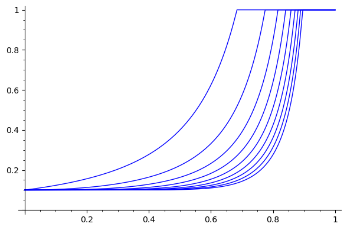

```python
sum([plot(min_symbolic(1,((n-1)*0.1*x^n+0.1)/(1-x^n)^2),(x,0,1),ymin=0,ymax=1) for n in range(1,10)])
```

$$b(x) = \begin{cases}\frac{(n-1)ax^n+a}{(1-x^n)^2} & x< x_\text{crit}\\ 1 & x \ge x_\text{crit} \end{cases} $$

### Proof of $n$-gambler solution

We assume gamblers 2...$n$ all use the optimal solution. When $x_1<x_\text{crit}$ we can show $u_1=-a$ regardless of the strategy.

$$ b(x)= \frac{nax^n}{(1-x^n)^2}+\frac{a}{(1-x^n)} $$

$$ b(x)= \frac{nax^n+(1-x^n)a}{(1-x^n)^2}$$

$$ b(x)= \frac{nax^n+a-ax^n}{(1-x^n)^2}$$

$$ b(x)= \frac{(n-1)ax^n+a}{(1-x^n)^2}$$

```python
var("x n a")
u1 = function("u1")(x)
forget()
assume(n>0)
assume(n,"integer")
assume(a>0)
assume(a<1)
assume(x>0)
assume(x<1)
assume(x>a)
b(x) = n*a*x^n/(1-x^n)^2+a/(1-x^n)
eq1 = (u1(x)==x^(n-1)*n*b.integral(x,0,x)-(1-x^n)*b)
show(eq1(x).simplify_full())
```

$$\newcommand{\Bold}[1]{\mathbf{#1}}u_{1}\left(x\right) = -a$$

# Conclusions

We have proven the Nash-equilibrium strategy in $n$-player simultaneous poker (as defined here). I have never seen this treatment anywhere else, and possibly for good reason. Are any of these insights useful for real poker, with turns and calling? I'd say maybe.

If your opponent ignored your actions and played solely by their hand, then this game could closely resemble 5-card stud. Of course, in real poker, randomization needs to be used to obfuscate. But what is the underlying basic strategy that needs to be obfuscated? I'd guess it looks something like the curves shown here.

Regardless, it is fun to consider this game on its own merits. The two-person version would be more fun if a button was held as the bets climbed until a player folded by releasing the button. This would be equivalent to the game above, but only in the 2-player case. The $n$-player case would become drastically more difficult to analyze.

Also, I like to think this game is somewhat related to dominance displays before fights in the animal kingdom. The connection is not perfect, but it is fun imagery.

There are clear directions for further investigations.

- Discretize the bets and hands.
- Have a more complex showdown. For example, the showdown could be a duel, where each player has 0 to 10 bullets, such that a better hand (more bullets) does not guarentee a win.
- Can the $n$-player strategy be colluded against successfully?